# Life Policy Book Analysis: Initial Lapse Investigation

Mick Cooney mickcooney@gmail.com

2018-01-04

# 1 Load Input Data

This worksheet loads up the data of the book of life insurance policies and some very basic data exploration.

```r
data_snapshot_date <- as.Date('2015-12-31')
```

With the original dataset we had all four product types: Protection, Savings, Pensions and Alternative Retirement Funds (ARFs).

In this analysis, we narrow the focus of our investigation into protection policies with monthly premium with sum assureds of less than one million euro as larger risks are generally subjected to more rigourous underwriting and tend to have different customer behaviour.

```r
lifebook_tbl <- read_feather("data/lifebook_cleaned.feather")

protection_book_tbl <- lifebook_tbl %>%
    filter(prod_type   == 'protection'
          ,prem_freq   == 12
          ,prem_type   == 'RP'
          ,sum_assured <= 1e6
           )

protection_book_tbl %>% glimpse
```

```
## Observations: 670,068
## Variables: 25
## $ policy_id               <chr> "C010000201", "C010000259", "C010000424", "C010000790...
## $ countyname              <chr> "South Dublin", "Cavan County", "Donegal County", "Wi...
## $ edname                  <chr> "Lucan-Esker", "Tullyvin East", "Killybegs", "Bray No...
## $ nuts3name               <chr> "Dublin", "Border", "Border", "Mid-East", "Mid-East",...
## $ sa_id                   <chr> "A267100077", "A027090001", "A057096009", "A257017025...
## $ cluster_id              <chr> "n6_c5", "n6_c1", "n6_c2", "n6_c5", "n6_c5", "n6_c3",...
## $ prod_type               <chr> "protection", "protection", "protection", "protection...
## $ prem_type               <chr> "RP", "RP", "RP", "RP", "RP", "RP", "RP", "RP", "RP",...
## $ prem_freq               <int> 12, 12, 12, 12, 12, 12, 12, 12, 12, 12, 12, 12, 12, 1...
## $ prem_ape                <dbl> 2825.19, 1772.83, 286.13, 968.72, 2135.58, 2299.68, 5...
## $ prem_risk               <dbl> 2017.991, 1266.308, 204.378, 691.944, 1525.415, 1642....
## $ policy_startdate        <date> 1990-01-02, 1990-01-02, 1990-01-02, 1990-01-02, 1990...
## $ policy_enddate          <date> 2010-01-02, 2010-01-02, 2010-01-02, 2010-01-02, 2010...
## $ policy_duration         <int> 20, 20, 20, 20, 20, 10, 20, 10, 15, 20, 14, 10, 20, 2...
## $ mort_rating             <int> 200, 200, 150, 100, 100, 200, 150, 100, 100, 100, 150...
## $ sum_assured             <dbl> 150000, 150000, 350000, 250000, 300000, 300000, 10000...
## $ dob_life1               <date> 1936-05-27, 1955-12-23, 1973-05-17, 1946-12-10, 1939...
## $ gender_life1            <chr> "M", "F", "M", "M", "M", "M", "F", "M", "F", "M", "M"...
## $ smoker_life1            <chr> "S", "S", "Q", "N", "N", "S", "Q", "N", "N", "N", "Q"...
## $ isjointlife             <lgl> FALSE, FALSE, FALSE, FALSE, FALSE, FALSE, FALSE, FALS...
## $ islifeonly              <lgl> TRUE, FALSE, TRUE, TRUE, TRUE, TRUE, FALSE, TRUE, TRU...
## $ mortgage_status         <chr> "MORTDECR", "MORTFULL", "MORTDECR", "MORTDECR", "MORT...
## $ policy_status           <chr> "completed", "completed", "completed", "lapsed", "lap...
## $ policy_statuschangedate <date> 2010-01-02, 2010-01-02, 2010-01-02, 1995-07-02, 1991...
## $ lapsed                  <lgl> FALSE, FALSE, FALSE, TRUE, TRUE, TRUE, TRUE, FALSE, F...
```

So we have 670,000 protection policies in our set for analysis.

This dataset will be the basis of our lapse investigation, but to do so we need to create a few extra derived variables.

## 1.1 Create Derived Values

Now that we have loaded the data we do a bit of feature engineering to calculate a few new and useful variables.

```r
protection_book_tbl <- protection_book_tbl %>%
    mutate(age_at_data_snapshot = as.numeric((data_snapshot_date - dob_life1) / 365.25)
          ,age_at_policy_start  = as.numeric((policy_startdate   - dob_life1) / 365.25)
          ,month_reached        = case_when(
              policy_status == 'lapsed'    ~ as.numeric(policy_statuschangedate - policy_startdate) / 30.4
             ,policy_status == 'completed' ~ as.numeric(policy_duration * 12)
             ,policy_status == 'inforce'   ~ as.numeric(data_snapshot_date - policy_startdate) / 30.4
                ) %>% round(0) %>% as.integer
    ) %>%
    filter(month_reached > 0)

protection_book_tbl %>% glimpse
```

[output not shown]

We now need to do some basic exploration of the variables before we model them.

## 1.2 Exploration of Derived Values

First we make some simple univariate plots of the derived values.

```r
dataexp_level_exclusion_threshold <- 100

dataexp_cat_level_count <- 40
dataexp_hist_bins_count <- 50
```

```
## --
## age_at_data_snapshot
##    Min. 1st Qu.  Median    Mean 3rd Qu.    Max.
##    16.1    45.4    53.2    53.2    61.0    96.2
```

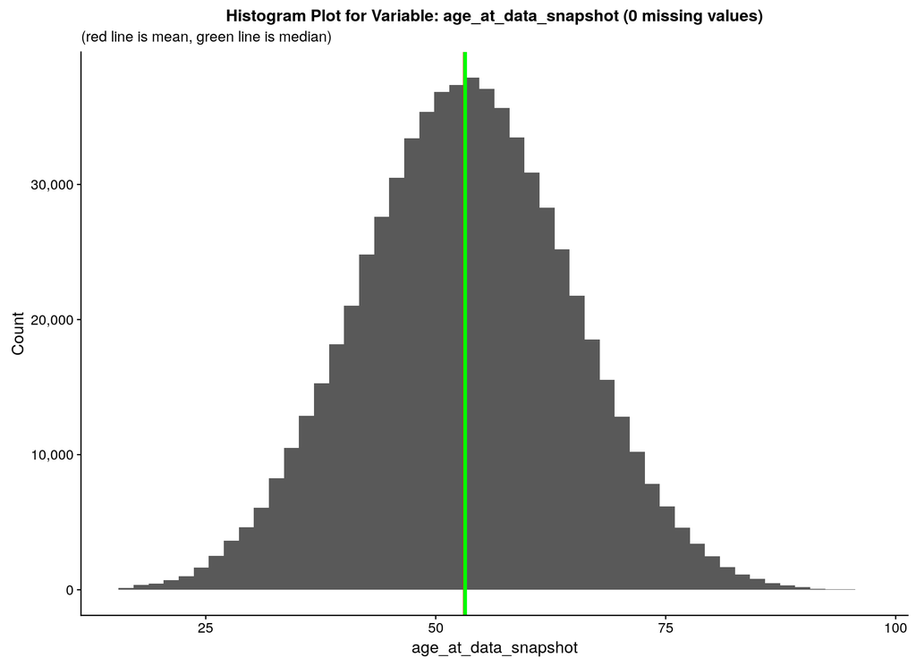

```
## --
## age_at_policy_start
##    Min. 1st Qu.  Median    Mean 3rd Qu.    Max.
##    16.0    33.7    40.5    40.5    47.2    70.9
```

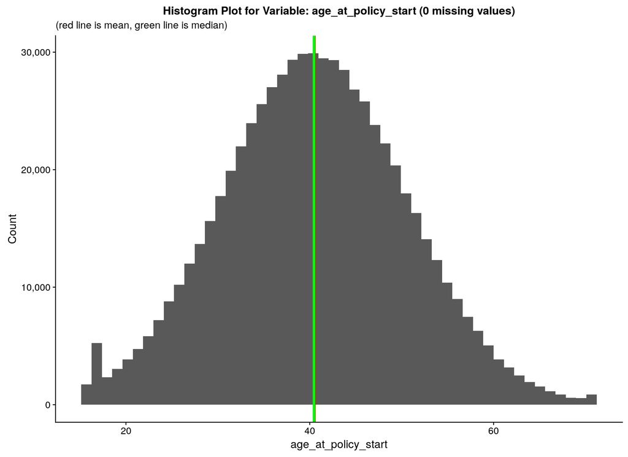

```
## --
## month_reached
##    Min. 1st Qu.  Median    Mean 3rd Qu.    Max.
##       1      39      93      95     140     240
```

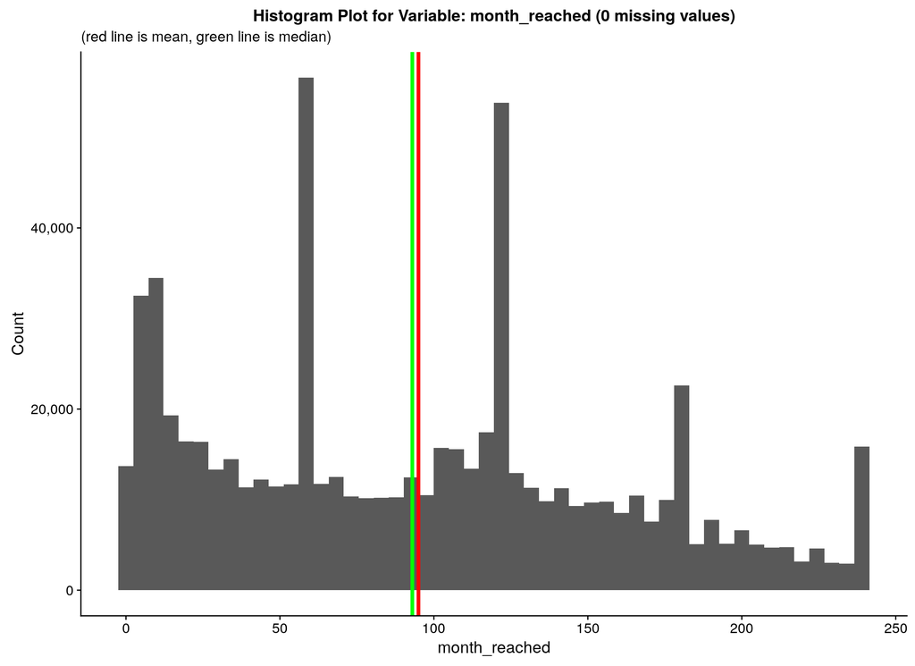

```r
derived_vars <- c('age_at_data_snapshot', 'age_at_policy_start', 'month_reached')

for(plot_varname in derived_vars) {
    cat("--\n")
    cat(paste0(plot_varname, '\n'))

    plot_var <- protection_book_tbl %>% .[[plot_varname]]
    na_count <- plot_var %>% is.na %>% sum

    plot_var %>% summary %>% print

    explore_plot <- ggplot(protection_book_tbl) +
        geom_histogram(aes_string(x = plot_varname), bins = dataexp_hist_bins_count) +
        geom_vline(xintercept = mean  (plot_var, na.rm = TRUE), colour = 'red',   size = 1.5) +
        geom_vline(xintercept = median(plot_var, na.rm = TRUE), colour = 'green', size = 1.5) +
        xlab(plot_varname) +
        ylab("Count") +
        scale_x_continuous(labels = comma) +
        scale_y_continuous(labels = comma) +
        ggtitle(paste0('Histogram Plot for Variable: ', plot_varname
                      ,' (', na_count, ' missing values)')
               ,subtitle = '(red line is mean, green line is median)')

    print(explore_plot)
}
```

## 1.3 Set Categorical Reference Levels

We want to set a reference level for each of the categorical variables in the dataset to aid with interpretation so we convert a number of the character variables to be factors with a given reference.

```r
protection_book_tbl <- protection_book_tbl %>%
    mutate(
        mortgage_status = mortgage_status %>% as_factor %>% relevel(ref = 'TERM')
       ,cluster_id      = cluster_id      %>% as_factor %>% relevel(ref = 'n6_c0')
       ,gender_life1    = gender_life1    %>% as_factor %>% relevel(ref = 'M')
       ,smoker_life1    = smoker_life1    %>% as_factor %>% relevel(ref = 'N')
        )
```

# 2 Initial Empirical Lapse Analysis

Prior to starting our model we want to look at the progression of monthly lapse rates.

To calculate this data we need to count the number of in-force policies during each month as well as the count of policies that lapsed in that month.

We do this by calculating the cumulative sum of policy starts in each month, as well as the counts of policies going out-of-force from lapses or reaching end-of-life. The difference of the two gives us a count of in-force policies on the book each month, and we then use this to calculate the empirical lapse rate.

Note that we round all dates to the start of the month and so there are slight timing issues around that, but we can ignore those for now.

```r
tstamp_first_month <- protection_book_tbl %>%
    pull(policy_startdate) %>%
    min() %>%
    format('%Y-%m-01') %>%
    as.Date()

tstamp_months_tbl <- data_frame(tstamp_month = seq(tstamp_first_month, data_snapshot_date, by = 'month'))


count_start_tbl <- protection_book_tbl %>%
    mutate(start_month  = policy_startdate %>% format("%Y-%m-01") %>% as.Date()) %>%
    count(start_month) %>%
    rename(start_count = n)

count_end_tbl <- protection_book_tbl %>%
    mutate(oof_date = case_when(
                policy_status == 'lapsed' ~ policy_statuschangedate
               ,TRUE                      ~ policy_enddate
                )
          ,oof_month = oof_date %>% format('%Y-%m-01') %>% as.Date()
    ) %>%
    count(oof_month) %>%
    rename(oof_count = n)


count_lapse_tbl <- protection_book_tbl %>%
    filter(policy_status == 'lapsed') %>%
    mutate(lapse_month = policy_statuschangedate %>% format('%Y-%m-01') %>% as.Date()) %>%
    count(lapse_month) %>%
    rename(lapse_count = n)


lapse_data_tbl <- tstamp_months_tbl %>%
    left_join(count_start_tbl, by = c('tstamp_month' = 'start_month')) %>%
    left_join(count_end_tbl,   by = c('tstamp_month' = 'oof_month')) %>%
    left_join(count_lapse_tbl, by = c('tstamp_month' = 'lapse_month')) %>%
    replace_na(list(start_count = 0, oof_count = 0, lapse_count = 0)) %>%
    mutate(inforce_count = cumsum(start_count) - cumsum(oof_count)
          ,lapse_rate    = lapse_count / inforce_count
          )
```

With the lapse data calculate we now want to look at the lapse rate.

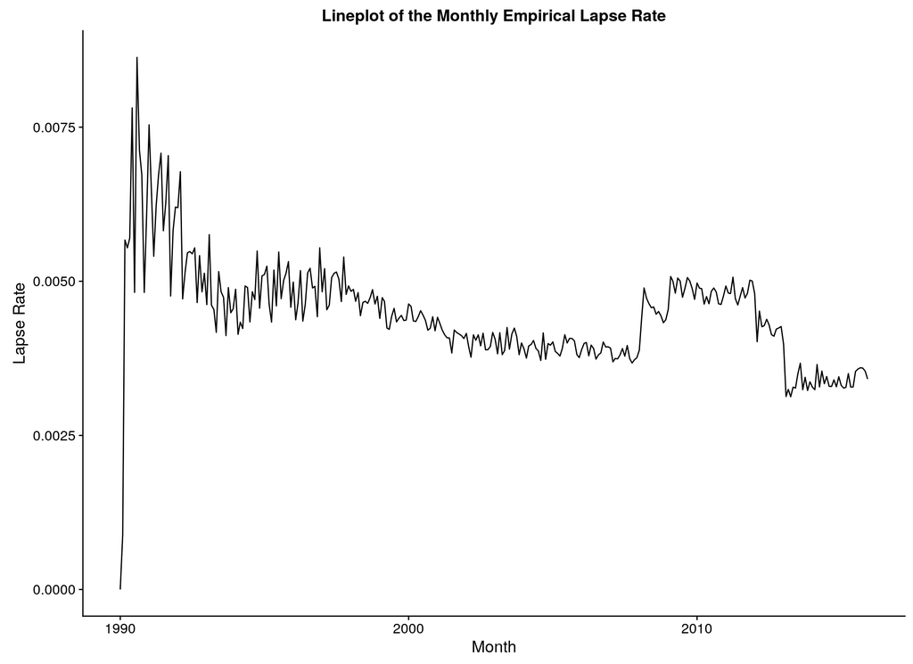

```r
ggplot(lapse_data_tbl) +
    geom_line(aes(x = tstamp_month, y = lapse_rate)) +
    expand_limits(y = 0) +
    xlab('Month') +
    ylab('Lapse Rate') +
    ggtitle('Lineplot of the Monthly Empirical Lapse Rate')
```

The early lapse rate is very noisy, probably due to the effects of the business starting up and so low policy counts. To check this, we need to look at time based effects of policy starts and the count of policies in force.

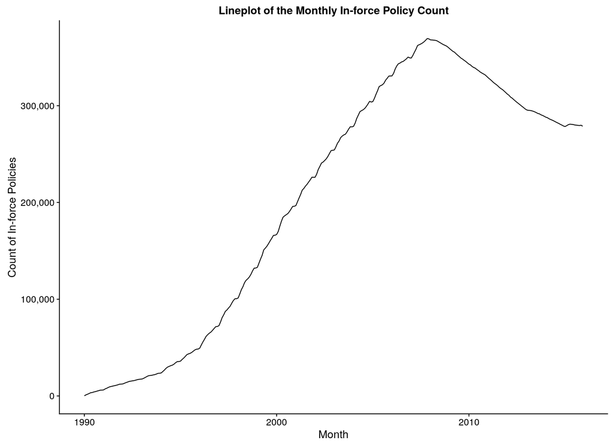

```r
ggplot(lapse_data_tbl) +
    geom_line(aes(x = tstamp_month, y = inforce_count)) +
    expand_limits(y = 0) +
    scale_y_continuous(labels = comma) +
     xlab('Month') +
    ylab('Count of In-force Policies') +
    ggtitle('Lineplot of the Monthly In-force Policy Count')
```

We see a steady increase in the inforce book, with it peaking around 2008 or so, declining after that. This may be due to a number of reasons, so we look at the patterns for new policies as well.

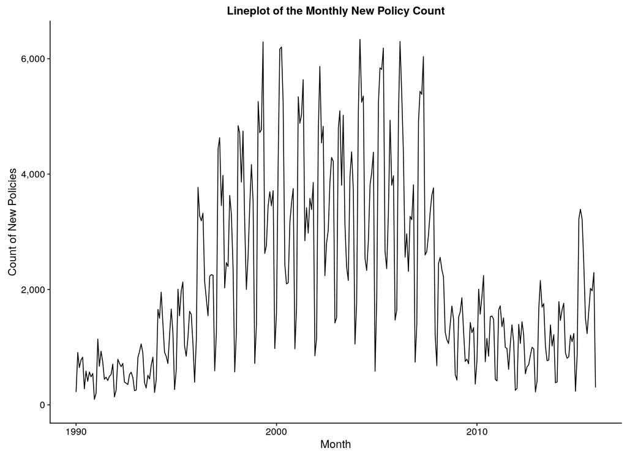

```r
ggplot(lapse_data_tbl) +
    geom_line(aes(x = tstamp_month, y = start_count)) +
    expand_limits(y = 0) +
    scale_y_continuous(labels = comma) +
    xlab('Month') +
    ylab('Count of New Policies') +
    ggtitle('Lineplot of the Monthly New Policy Count')
```

This makes sense for Ireland as this coincides with a huge property boom during that period, which fuelled a huge demand for life insurance tied to mortgages.

As a final comparison, we will plot both the lapse rate and the count of in-force policies together on a single panel plot. We plot from the start of 1996 to reduce the effects of the initial years from the plot

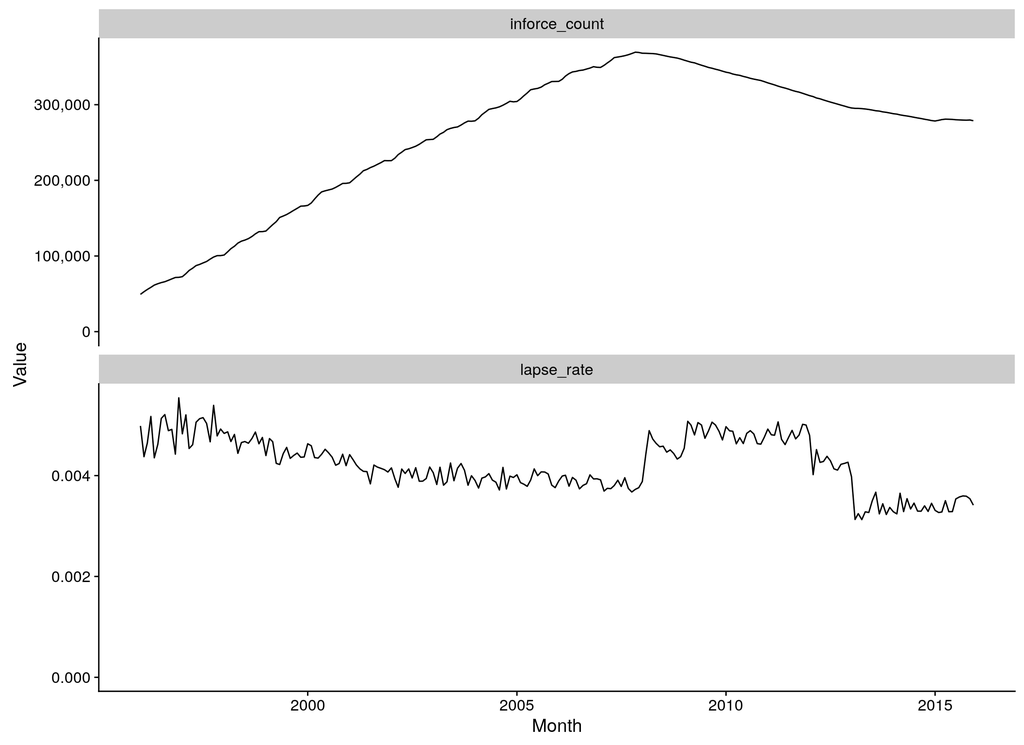

```r
plot_tbl <- lapse_data_tbl %>%
    filter(tstamp_month >= as.Date('1996-01-01')) %>%
    dplyr::select(tstamp_month, lapse_rate, inforce_count) %>%
    gather('key', 'value', -tstamp_month)

ggplot(plot_tbl) +
    geom_line(aes(x = tstamp_month, y = value)) +
    expand_limits(y = 0) +
    facet_wrap(~key, ncol = 1, scales = 'free_y') +
    scale_y_continuous(labels = comma) +
    xlab('Month') +
    ylab('Value')
```

## 2.1 Investigating the Recession

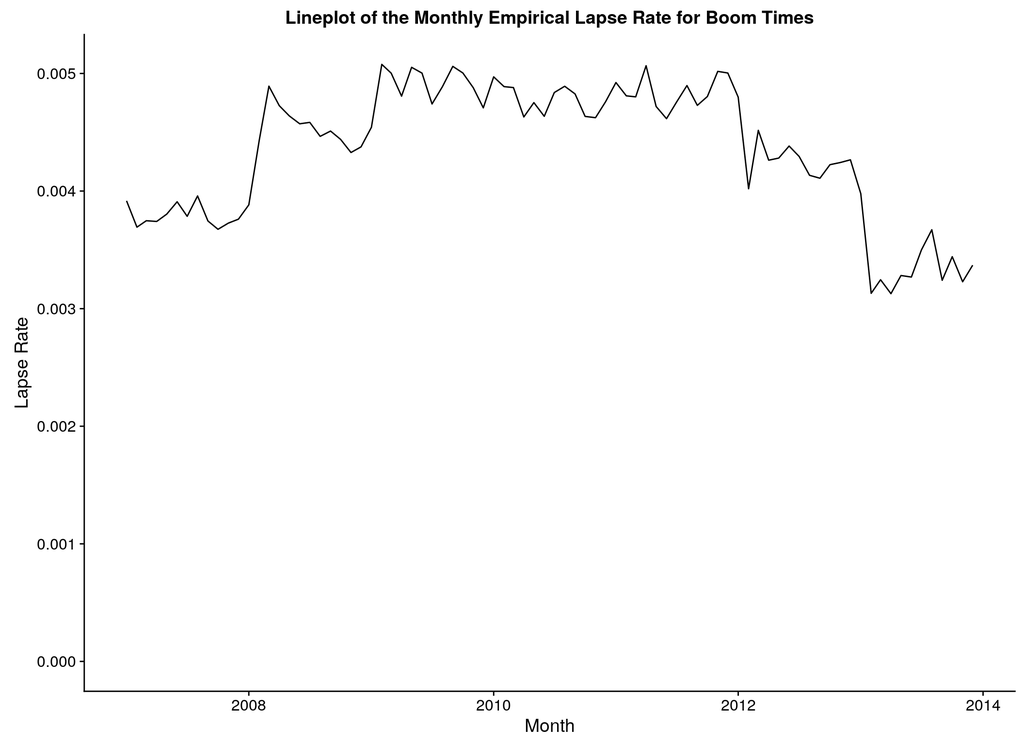

```r
ggplot(lapse_data_tbl %>% filter(tstamp_month >= as.Date('2007-01-01')
                                ,tstamp_month <= as.Date('2013-12-31'))) +
    geom_line(aes(x = tstamp_month, y = lapse_rate)) +
    expand_limits(y = 0) +
    xlab('Month') +
    ylab('Lapse Rate') +
    ggtitle('Lineplot of the Monthly Empirical Lapse Rate for Boom Times')
```

Looking at this data, it seems reasonable to flag the recession as starting at the beginning of 2008 and ending at the end of 2012.

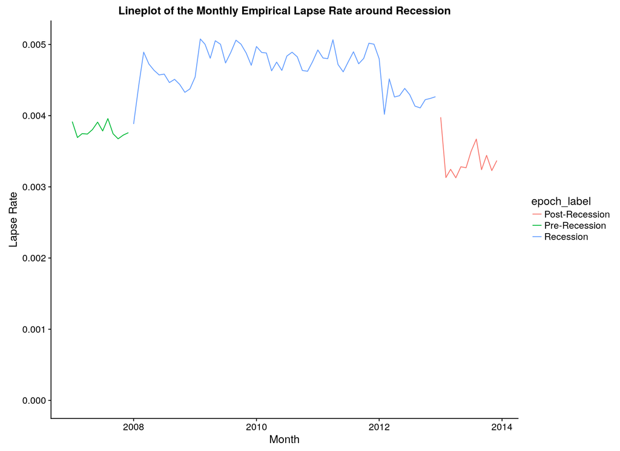

```r
lapse_data_tbl <- lapse_data_tbl %>%
    mutate(epoch_label = case_when(
               tstamp_month <  as.Date('2008-01-01')       ~ 'Pre-Recession'
              ,tstamp_month >= as.Date('2008-01-01') &
               tstamp_month <= as.Date('2012-12-31')       ~ 'Recession'
              ,TRUE                                        ~ 'Post-Recession'
            )
        )


ggplot(lapse_data_tbl %>% filter(tstamp_month >= as.Date('2007-01-01')
                                ,tstamp_month <= as.Date('2013-12-31'))) +
    geom_line(aes(x = tstamp_month, y = lapse_rate, colour = epoch_label)) +
    expand_limits(y = 0) +
    xlab('Month') +
    ylab('Lapse Rate') +
    ggtitle('Lineplot of the Monthly Empirical Lapse Rate around Recession')
```

These epochs will be useful later when accounting for the recession in future models.

## 2.2 Data Censorship

In the case where the amount of censoring is small relative to the size of the dataset we could potentially ignore it, otherwise our modelling will need to account for this phenomenon in the data.

To check the prevalence of censoring, we do a simple check of the proportions of the different policy statuses in our data.

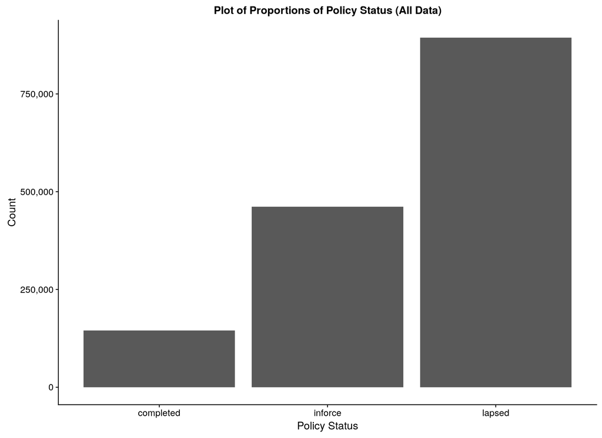

```r
ggplot(lifebook_tbl %>% count(policy_status)) +
    geom_col(aes(x = policy_status, y = n)) +
    scale_y_continuous(labels = comma) +
    xlab('Policy Status') +
    ylab('Count') +
    ggtitle('Plot of Proportions of Policy Status (All Data)')
```

Looking at all the data, it appears there is significant censoring. That said, we may decide that older lapse patterns are different from today, and so we restrict this plot to more recent policies (say from 2000 on and from 2005 on)

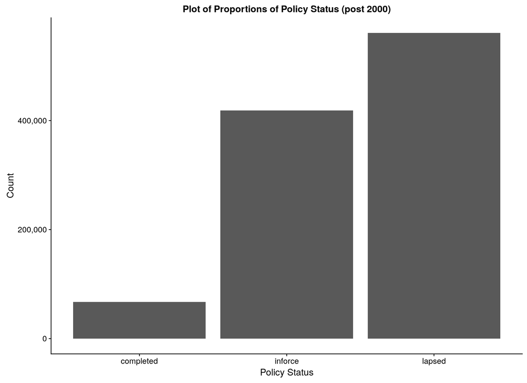

```r
ggplot(lifebook_tbl %>% filter(policy_startdate >= as.Date('2000-01-01')) %>% count(policy_status)) +
    geom_col(aes(x = policy_status, y = n)) +
    scale_y_continuous(labels = comma) +
    xlab('Policy Status') +
    ylab('Count') +
    ggtitle('Plot of Proportions of Policy Status (post 2000)')
```

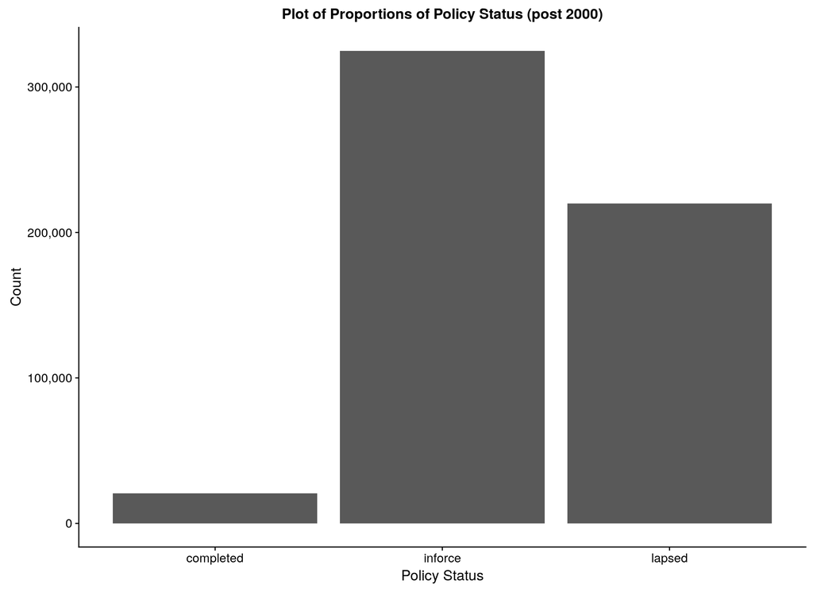

```r
ggplot(lifebook_tbl %>% filter(policy_startdate >= as.Date('2005-01-01')) %>% count(policy_status)) +
    geom_col(aes(x = policy_status, y = n)) +
    scale_y_continuous(labels = comma) +
    xlab('Policy Status') +
    ylab('Count') +
    ggtitle('Plot of Proportions of Policy Status (post 2000)')
```

Focusing on more recent policies we see that censoring becomes more and more important, so we need to account for this in our modelling.

For this reason, we will look at various survival analysis techniques as these naturally allow for the censorship of the data.

Before we move on to more formal modelling, it is interesting to see the difference between censored and non-censored observations in the data.

To do that, we create two histograms and look at the different distributions.

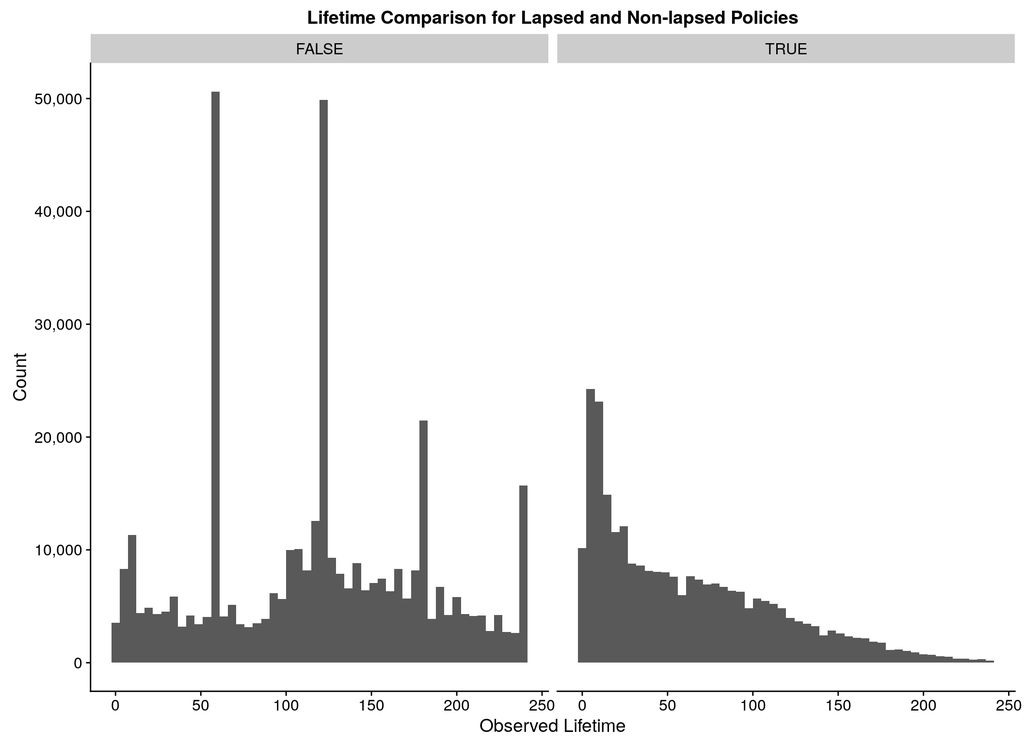

```r
ggplot(protection_book_tbl) +
    geom_histogram(aes(x = month_reached), bins = 50) +
    facet_wrap(~ lapsed, ncol = 2) +
    scale_y_continuous(labels = comma) +
    xlab("Observed Lifetime") +
    ylab("Count") +
    ggtitle("Lifetime Comparison for Lapsed and Non-lapsed Policies")
```

Once more we filter out the older policies in the book, and look at post-2000 and post-2005 policies:

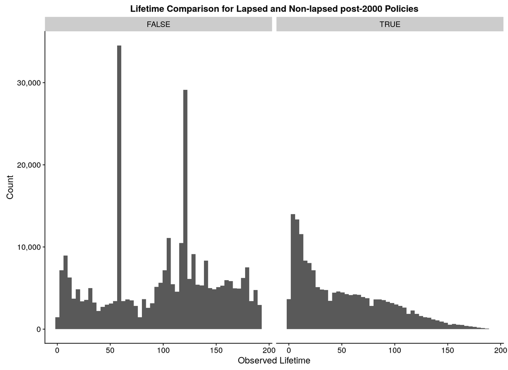

```r
ggplot(protection_book_tbl %>% filter(policy_startdate >= as.Date('2000-01-01'))) +
    geom_histogram(aes(x = month_reached), bins = 50) +
    facet_wrap(~ lapsed, ncol = 2) +
    scale_y_continuous(labels = comma) +
    xlab("Observed Lifetime") +
    ylab("Count") +
    ggtitle("Lifetime Comparison for Lapsed and Non-lapsed post-2000 Policies")
```

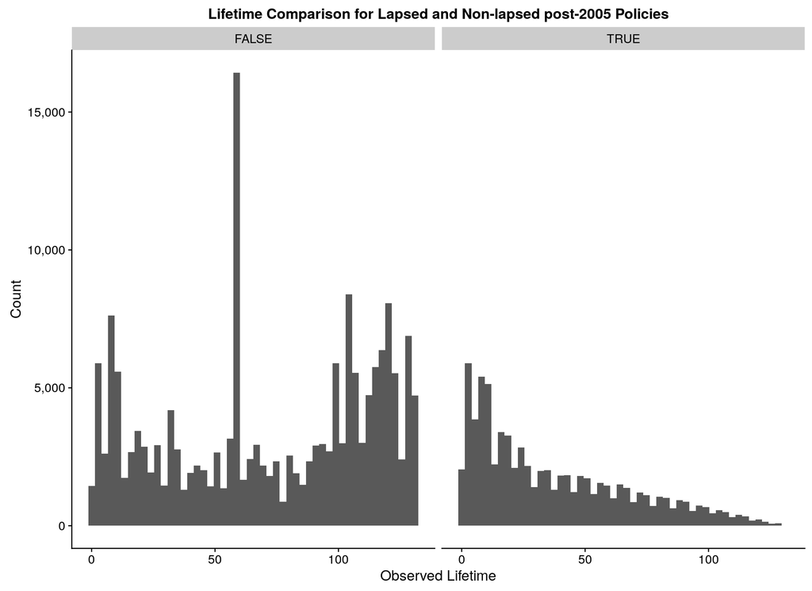

```r
ggplot(protection_book_tbl %>% filter(policy_startdate >= as.Date('2005-01-01'))) +
    geom_histogram(aes(x = month_reached), bins = 50) +
    facet_wrap(~ lapsed, ncol = 2) +
    scale_y_continuous(labels = comma) +
    xlab("Observed Lifetime") +
    ylab("Count") +
    ggtitle("Lifetime Comparison for Lapsed and Non-lapsed post-2005 Policies")
```

# 3 Using Survival Analysis Techniques

Having done our preliminary analysis, we now turn our attention to the use of survival analysis techniques to tackle this problem as a large proportion of our data is censored.

## 3.1 Kaplan-Meier Estimates

One of the first things we can look at is the Kaplan-Meier estimates for this data, first looking at the all the data without splitting along any categorical variables.

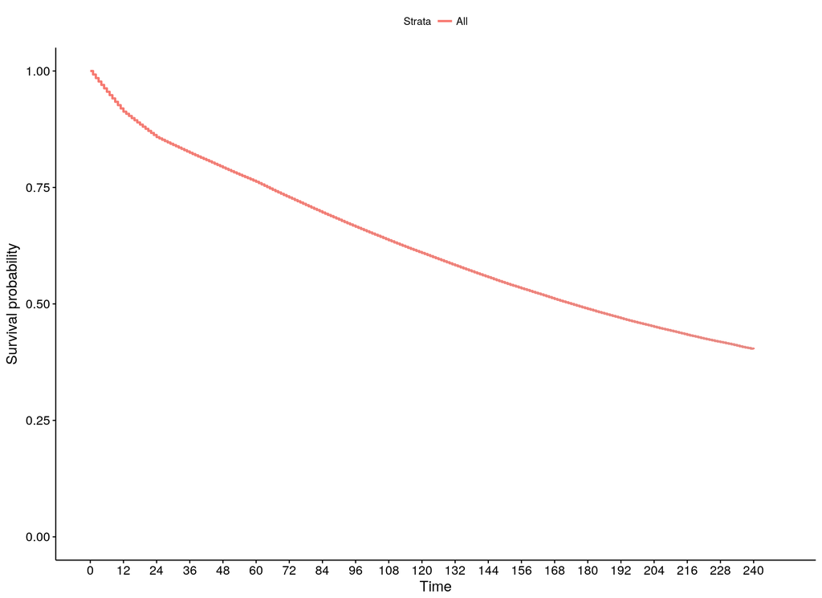

```r
lapse_basic_km <- survfit(Surv(month_reached, lapsed) ~ 1
                         ,data = protection_book_tbl)

ggsurvplot(lapse_basic_km, censor = FALSE, break.time.by = 12, conf.int = TRUE)
```

Now we look at alternative KM estimates, splitting the data on both gender and the smoking status of the primary policy holder.

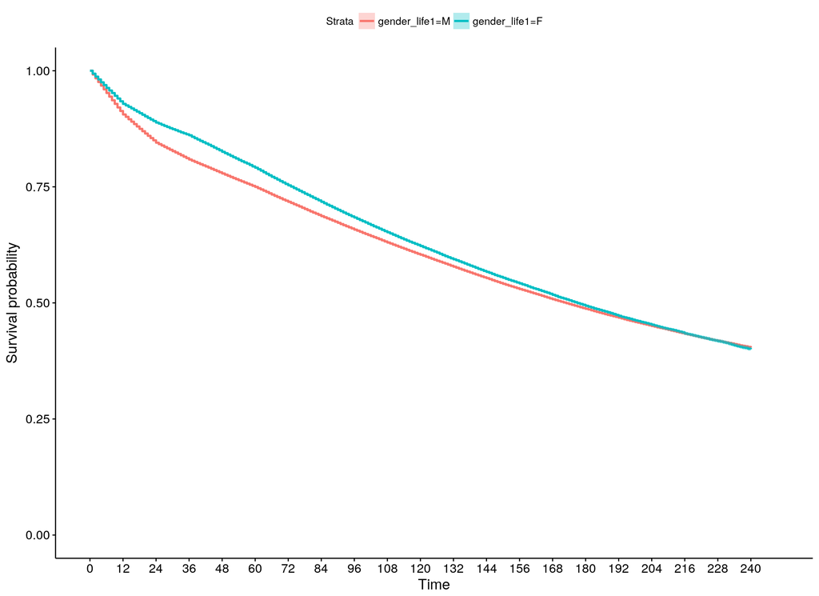

```r
lapse_gender_km <- survfit(Surv(month_reached, lapsed) ~ gender_life1
                          ,data = protection_book_tbl)

ggsurvplot(lapse_gender_km, censor = FALSE, break.time.by = 12, conf.int = TRUE)
```

We can see distinct differences between male and female policy holders in terms of expected time to lapse, especially for in the periods between 12-60 months. This is likely affected by differences in premium charged as before the 2012 Gender Price Directive, gender was a big price differentiator for life insurance policies and we surmise that a higher premium raises the likelihood of a policy lapsing.

We now move on to investigating lapse differences for smokers.

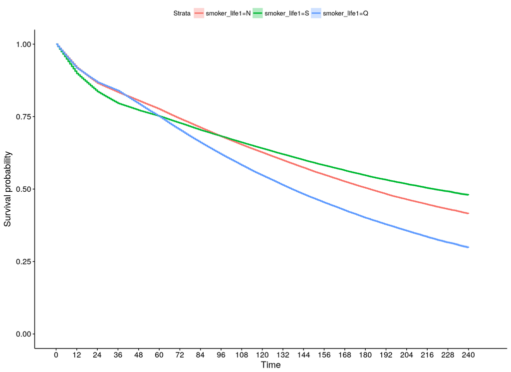

```r
lapse_smoker_km <- survfit(Surv(month_reached, lapsed) ~ smoker_life1
                          ,data = protection_book_tbl)

ggsurvplot(lapse_smoker_km, censor = FALSE, break.time.by = 12, conf.int = TRUE)
```

# 4 Cox Proportional Hazards Model

We now want to look at building regression models for our data, so we first split our data into the traditional machine-learning train/test split.

```r
test_prop <- 0.4

split_lst <- protection_book_tbl %>%
    resample_partition(c(train = 1 - test_prop, test = test_prop))

train_tbl <- split_lst$train %>% as_data_frame()
test_tbl  <- split_lst$test  %>% as_data_frame()
```

We output the split for later use in further worksheets.

```r
split_lst$train %>% as_data_frame %>% write_feather(path = 'data/protection_train.feather')
split_lst$test  %>% as_data_frame %>% write_feather(path = 'data/protection_test.feather')
```

## 4.1 Initial Exploratory Models

To get a feel for the types of models we want to build and how they might work, we focus initially on the `gender` and `smoker` variables to start.

Note that we are still very much in the ‘exploration’ phase: the purposes of these models is to get a feel for the data - we are not yet moving on to producing models for the purposes of prediction just yet.

For our first model, we simply fit the data to the gender parameter:

```r
basic_01_coxph <- coxph(Surv(month_reached, lapsed) ~ gender_life1
                       ,data = train_tbl
                        )

basic_01_coxph %>% summary()
```

```
## Call:
## coxph(formula = Surv(month_reached, lapsed) ~ gender_life1, data = train_tbl)
##
##   n= 401865, number of events= 159926
##
##                   coef exp(coef) se(coef)     z Pr(>|z|)
## gender_life1F -0.08077   0.92241  0.00551 -14.7   <2e-16 ***
## ---
## Signif. codes:  0 '***' 0.001 '**' 0.01 '*' 0.05 '.' 0.1 ' ' 1
##
##               exp(coef) exp(-coef) lower .95 upper .95
## gender_life1F     0.922       1.08     0.913     0.932
##
## Concordance= 0.515  (se = 0.001 )
## Rsquare= 0.001   (max possible= 1 )
## Likelihood ratio test= 217  on 1 df,   p=<2e-16
## Wald test            = 215  on 1 df,   p=<2e-16
## Score (logrank) test = 215  on 1 df,   p=<2e-16
```

```r
basic_01_coxph %>% tidy()
```

```
##            term   estimate  std.error statistic     p.value   conf.low  conf.high
## 1 gender_life1F -0.0807703 0.00550873  -14.6622 1.12527e-48 -0.0915672 -0.0699733
```

```r
basic_01_coxph %>% glance()
```

```
##        n nevent statistic.log p.value.log statistic.sc  p.value.sc statistic.wald
## 1 401865 159926       217.378 3.37534e-49      215.098 1.06111e-48         214.98
##   p.value.wald   r.squared r.squared.max concordance std.error.concordance   logLik
## 1  1.12527e-48 0.000540777      0.999946    0.515043           0.000621362 -1975349
##       AIC     BIC
## 1 3950699 3950709
```

The concordance index for this model is about 0.51 - only slightly above the reference level of 0.50, so this model contains little in the way of predictive power.

We also want to add smoking status, so we try that. We will look at its effect as the sole predictor first.

```r
basic_02_coxph <- coxph(Surv(month_reached, lapsed) ~ smoker_life1
                       ,data = train_tbl
                        )

basic_02_coxph %>% summary()
```

```
## Call:
## coxph(formula = Surv(month_reached, lapsed) ~ smoker_life1, data = train_tbl)
##
##   n= 401865, number of events= 159926
##
##                   coef exp(coef) se(coef)     z Pr(>|z|)
## smoker_life1S -0.03945   0.96132  0.00618 -6.38  1.7e-10 ***
## smoker_life1Q  0.23227   1.26146  0.00593 39.18  < 2e-16 ***
## ---
## Signif. codes:  0 '***' 0.001 '**' 0.01 '*' 0.05 '.' 0.1 ' ' 1
##
##               exp(coef) exp(-coef) lower .95 upper .95
## smoker_life1S     0.961      1.040      0.95     0.973
## smoker_life1Q     1.261      0.793      1.25     1.276
##
## Concordance= 0.513  (se = 0.001 )
## Rsquare= 0.005   (max possible= 1 )
## Likelihood ratio test= 2018  on 2 df,   p=<2e-16
## Wald test            = 2085  on 2 df,   p=<2e-16
## Score (logrank) test = 2096  on 2 df,   p=<2e-16
```

```r
basic_02_coxph %>% tidy()
```

```
##            term   estimate  std.error statistic     p.value   conf.low  conf.high
## 1 smoker_life1S -0.0394492 0.00617855  -6.38486 1.71555e-10 -0.0515589 -0.0273394
## 2 smoker_life1Q  0.2322672 0.00592805  39.18106 0.00000e+00  0.2206485  0.2438860
```

```r
basic_02_coxph %>% glance()
```

```
##        n nevent statistic.log p.value.log statistic.sc p.value.sc statistic.wald
## 1 401865 159926       2018.38           0      2095.79          0        2085.02
##   p.value.wald  r.squared r.squared.max concordance std.error.concordance   logLik
## 1            0 0.00500993      0.999946    0.513039           0.000722779 -1974448
##       AIC     BIC
## 1 3948900 3948920
```

Once again we have a low concordance index for this model, so we need to do better.

We do have a socio-economic clustering in this data, and we do know that this had a profound effect on the economy with young families losing their job and forgoing their mortgage for example, so we look at that.

```r
basic_03_coxph <- coxph(
    Surv(month_reached, lapsed) ~ cluster_id
   ,data = train_tbl
                        )

basic_03_coxph %>% summary()
```

```
## Call:
## coxph(formula = Surv(month_reached, lapsed) ~ cluster_id, data = train_tbl)
##
##   n= 401865, number of events= 159926
##
##                     coef exp(coef) se(coef)      z Pr(>|z|)
## cluster_idn6_c5  0.45336   1.57358  0.00688  65.87   <2e-16 ***
## cluster_idn6_c1  0.00595   1.00597  0.00892   0.67     0.51
## cluster_idn6_c2  0.00239   1.00239  0.00827   0.29     0.77
## cluster_idn6_c3 -0.01514   0.98497  0.01086  -1.39     0.16
## cluster_idn6_c4 -0.29978   0.74098  0.01016 -29.50   <2e-16 ***
## ---
## Signif. codes:  0 '***' 0.001 '**' 0.01 '*' 0.05 '.' 0.1 ' ' 1
##
##                 exp(coef) exp(-coef) lower .95 upper .95
## cluster_idn6_c5     1.574      0.635     1.553     1.595
## cluster_idn6_c1     1.006      0.994     0.989     1.024
## cluster_idn6_c2     1.002      0.998     0.986     1.019
## cluster_idn6_c3     0.985      1.015     0.964     1.006
## cluster_idn6_c4     0.741      1.350     0.726     0.756
##
## Concordance= 0.562  (se = 0.001 )
## Rsquare= 0.024   (max possible= 1 )
## Likelihood ratio test= 9588  on 5 df,   p=<2e-16
## Wald test            = 9820  on 5 df,   p=<2e-16
## Score (logrank) test = 10063  on 5 df,   p=<2e-16
```

```r
basic_03_coxph %>% tidy()
```

```
##              term    estimate  std.error  statistic      p.value   conf.low   conf.high
## 1 cluster_idn6_c5  0.45335536 0.00688217  65.873895  0.00000e+00  0.4398666  0.46684416
## 2 cluster_idn6_c1  0.00594886 0.00892470   0.666561  5.05052e-01 -0.0115432  0.02344094
## 3 cluster_idn6_c2  0.00239185 0.00827426   0.289072  7.72527e-01 -0.0138254  0.01860911
## 4 cluster_idn6_c3 -0.01514259 0.01085732  -1.394690  1.63109e-01 -0.0364225  0.00613737
## 5 cluster_idn6_c4 -0.29977736 0.01016337 -29.495864 3.25295e-191 -0.3196972 -0.27985752
```

```r
basic_03_coxph %>% glance()
```

```
##        n nevent statistic.log p.value.log statistic.sc p.value.sc statistic.wald
## 1 401865 159926       9588.38           0      10062.8          0        9819.54
##   p.value.wald r.squared r.squared.max concordance std.error.concordance   logLik     AIC
## 1            0 0.0235773      0.999946    0.561824           0.000762407 -1970663 3941336
##       BIC
## 1 3941386
```

The concordance index is now over 0.56 so the cluster of the policy owner contains predictive power for the propensity of the policy to lapse.

We now look at the model with all three predictors combined as predictors in the model.

```r
basic_04_coxph <- coxph(
    Surv(month_reached, lapsed) ~ gender_life1 + smoker_life1 + cluster_id
   ,data = train_tbl
)
```

## 4.2 Testing the Model Assumptions

Another possible reason for the lack of predictive power in the model is because the assumptions in the model may not hold.

The main assumption of the CoxPH models is for the coefficients of the model to be constant over time. We first check the univariate model with gender:

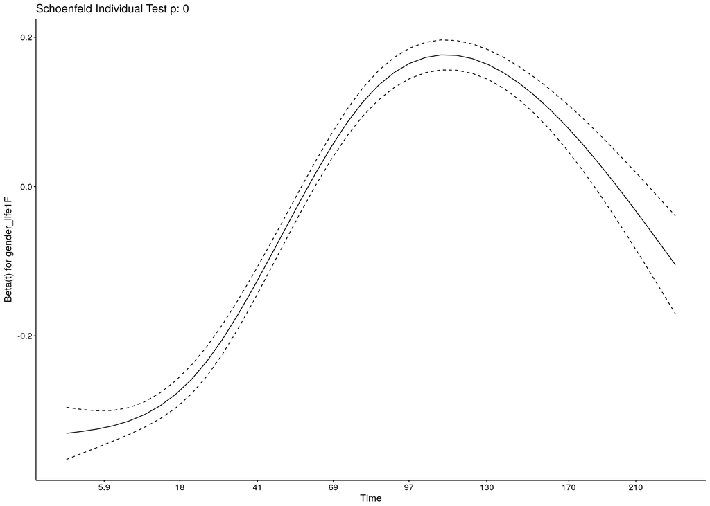

```r
basic_01_coxph %>% cox.zph() %>% ggcoxzph(resid = FALSE)
```

It is pretty clear that gender has an effect, but is not a time-independent effect. This is something we will need to deal with somehow.

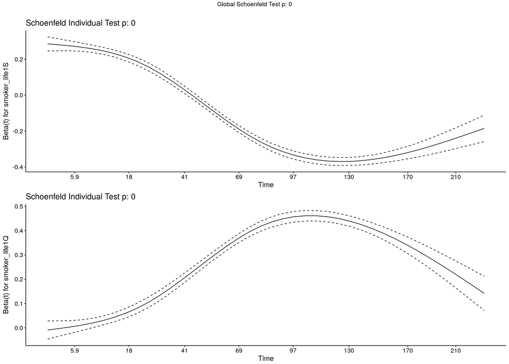

```r
basic_02_coxph %>% cox.zph() %>% ggcoxzph(resid = FALSE)
```

Smoking status seems very similar to gender - there is an effect, but it not time-independent.

We look at the clustering now.

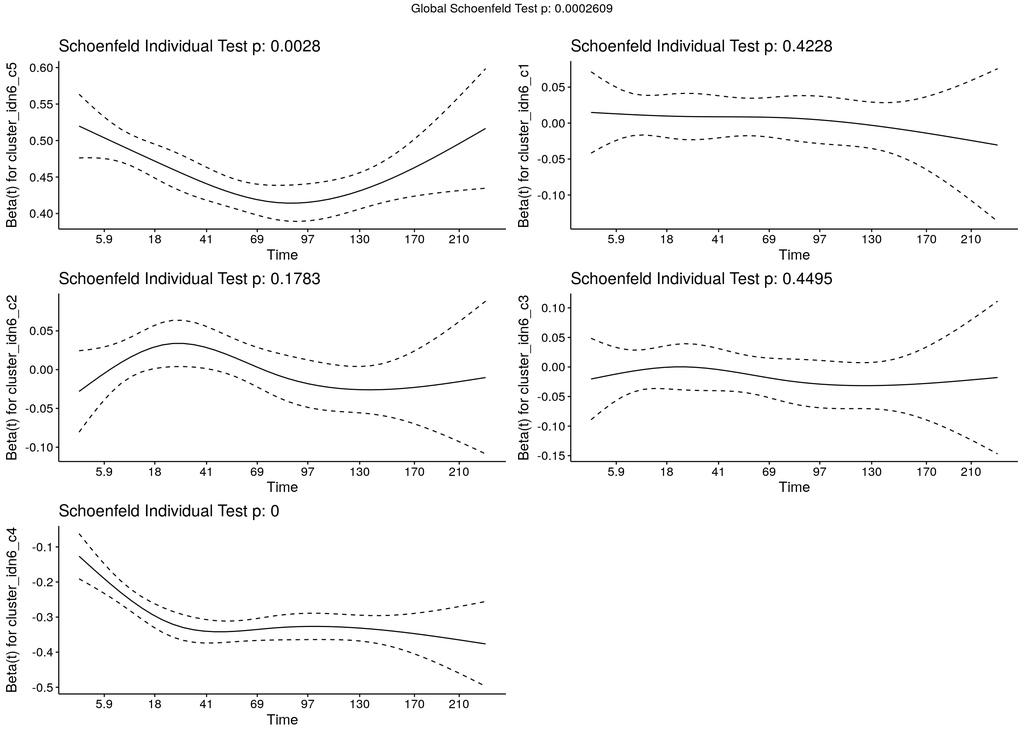

```r
basic_03_coxph %>% cox.zph() %>% ggcoxzph(resid = FALSE)
```

The clustering is around 0 for some of the levels, but the signification ones are not time-independent.

Finally, we look at the combined model, which we expect to give us a similar message.

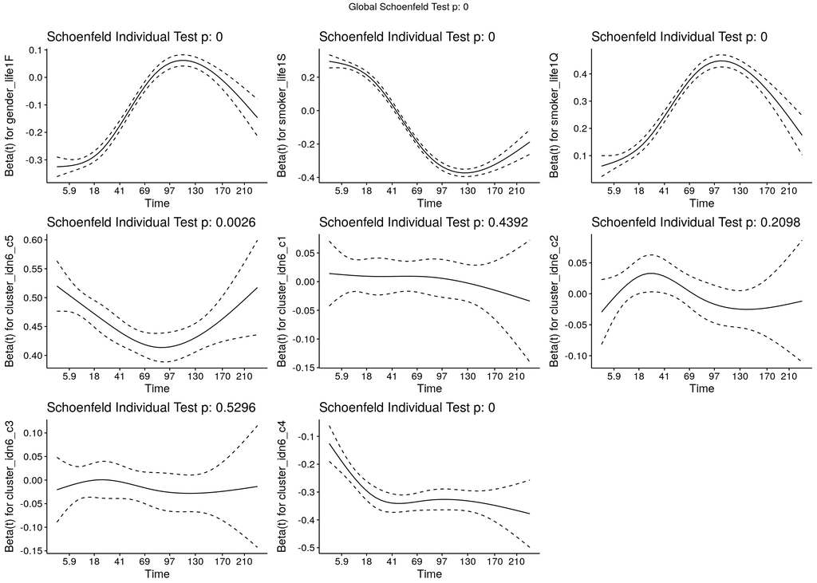

```r
basic_04_coxph %>% cox.zph() %>% ggcoxzph(resid = FALSE)
```

## 4.3 Using the Secret Weapon

We now use a simple technique known as the ‘Secret Weapon’ by Andrew Gelman. With this method we partition the data along various dimensions, fitting the same model to each partition and then plotting coefficients together to get a sense of the variability.

We know that the CoxPH model has issues as it violates the assumptions of the model, but it is likely to be instructive anyway. We will almost make a plot of the concordance index as well as the p-value from the `cox.zph()` test to see if there are any calendar patterns to the violation of the assumptions.

```r
secretweapon_year_lst <- split_lst$train %>%
    as_data_frame() %>%
    mutate(split_label = format(policy_startdate, '%Y')) %>%
    split(.$split_label) %>%
    map(~ coxph(Surv(month_reached, lapsed) ~ gender_life1 + smoker_life1 + cluster_id
               ,data = .))

coefs_tbl <- secretweapon_year_lst %>%
    map(tidy) %>%
    bind_rows(.id = 'start_year')

metrics_tbl <- secretweapon_year_lst %>%
    map(glance) %>%
    bind_rows(.id = 'start_year') %>%
    transmute(start_year
             ,term      = 'concordance'
             ,estimate  = concordance
             ,std.error = std.error.concordance)

secretweapon_year_tbl <- list(coefs_tbl, metrics_tbl) %>%
    bind_rows() %>%
    mutate(start_year = start_year %>% as.integer)
```

Having calculated both the parameter coefficients and the concordance index after splitting the data by policy year, we now plot the coefficients of the model as well as the concordance index, including the error bars.

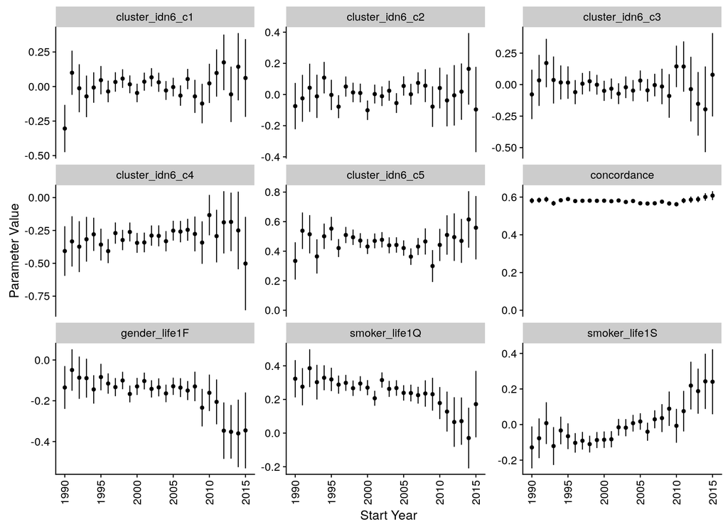

```r
ggplot(secretweapon_year_tbl) +
    geom_point(aes(x = start_year, y = estimate)) +
    geom_errorbar(aes(x    = start_year
                     ,ymin = estimate - 2 * std.error
                     ,ymax = estimate + 2 * std.error)
                 ,width = 0) +
    expand_limits(y = 0) +
    facet_wrap(~term, scales='free_y') +
    xlab("Start Year") +
    ylab("Parameter Value") +
    theme(axis.text.x = element_text(angle = 90, vjust = 0.5))
```

Finally, we do a plot of the p-values from the `cox.zph()` test and construct the same plot.

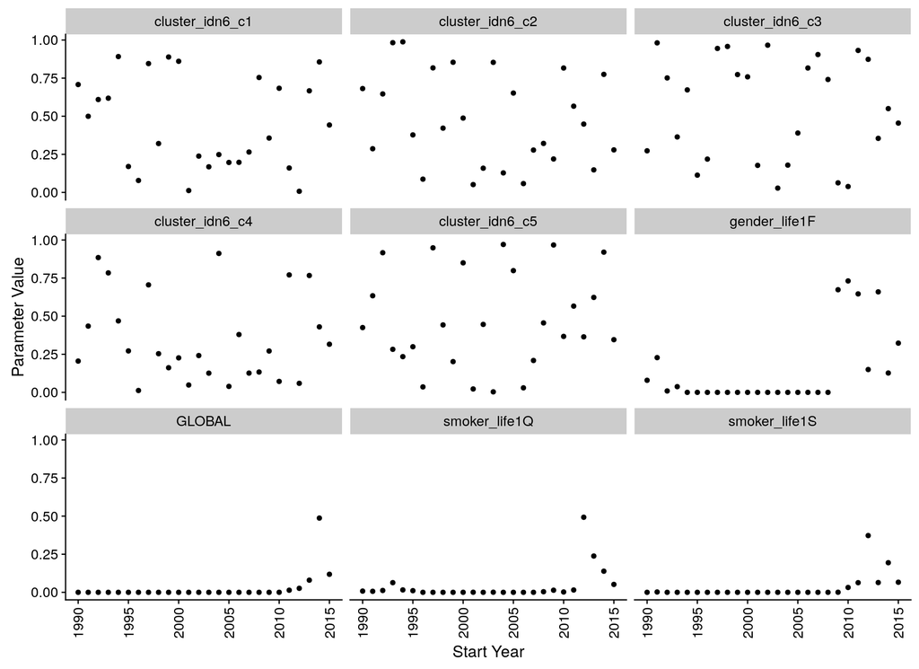

```r
extract_test_values <- function(input) {
    test_tbl <- input %>%
        cox.zph() %>%
        .$table %>%
        as.data.frame() %>%
        rownames_to_column('term')

    return(test_tbl)
}


secretweapon_year_test_tbl <- secretweapon_year_lst %>%
    map(extract_test_values) %>%
    bind_rows(.id = 'start_year') %>%
    mutate(start_year = start_year %>% as.integer)


ggplot(secretweapon_year_test_tbl) +
    geom_point(aes(x = start_year, y = p)) +
    expand_limits(y = 0) +
    facet_wrap(~term) +
    xlab("Start Year") +
    ylab("Parameter Value") +
    theme(axis.text.x = element_text(angle = 90, vjust = 0.5))
```